Note

Go to the end to download the full example code. or to run this example in your browser via JupyterLite or Binder

# Compare cross decomposition methods

Simple usage of various cross decomposition algorithms:

- PLSCanonical
- PLSRegression, with multivariate response, a.k.a. PLS2
- PLSRegression, with univariate response, a.k.a. PLS1
- CCA

Given 2 multivariate covarying two-dimensional datasets, X, and Y, PLS extracts the ‘directions of covariance’, i.e. the components of each datasets that explain the most shared variance between both datasets. This is apparent on the **scatterplot matrix** display: components 1 in dataset X and dataset Y are maximally correlated (points lie around the first diagonal). This is also true for components 2 in both dataset, however, the correlation across datasets for different components is weak: the point cloud is very spherical.

```
# Authors: The scikit-learn developers
# SPDX-License-Identifier: BSD-3-Clause
```

## Dataset based latent variables model

```
import numpy as np

n = 500
# 2 latents vars:
l1 = np.random.normal(size=n)
l2 = np.random.normal(size=n)

latents = np.array([l1, l1, l2, l2]).T
X = latents + np.random.normal(size=4 * n).reshape((n, 4))
Y = latents + np.random.normal(size=4 * n).reshape((n, 4))

X_train = X[: n // 2]
Y_train = Y[: n // 2]
X_test = X[n // 2 :]
Y_test = Y[n // 2 :]

print("Corr(X)")
print(np.round(np.corrcoef(X.T), 2))
print("Corr(Y)")
print(np.round(np.corrcoef(Y.T), 2))
```

```
Corr(X)
[[ 1.    0.45 -0.04  0.  ]
 [ 0.45  1.   -0.1  -0.02]
 [-0.04 -0.1   1.    0.42]
 [ 0.   -0.02  0.42  1.  ]]
Corr(Y)
[[ 1.    0.48 -0.12 -0.05]
 [ 0.48  1.    0.07  0.04]
 [-0.12  0.07  1.    0.5 ]
 [-0.05  0.04  0.5   1.  ]]
```

## Canonical (symmetric) PLS

### Transform data

```
from sklearn.cross_decomposition import PLSCanonical

plsca = PLSCanonical(n_components=2)
plsca.fit(X_train, Y_train)
X_train_r, Y_train_r = plsca.transform(X_train, Y_train)
X_test_r, Y_test_r = plsca.transform(X_test, Y_test)
```

### Scatter plot of scores

```
import matplotlib.pyplot as plt

# On diagonal plot X vs Y scores on each components
plt.figure(figsize=(12, 8))
plt.subplot(221)
plt.scatter(X_train_r[:, 0], Y_train_r[:, 0], label="train", marker="o", s=25)
plt.scatter(X_test_r[:, 0], Y_test_r[:, 0], label="test", marker="o", s=25)
plt.xlabel("x scores")
plt.ylabel("y scores")
plt.title(
    "Comp. 1: X vs Y (test corr = %.2f)"
    % np.corrcoef(X_test_r[:, 0], Y_test_r[:, 0])[0, 1]
)
plt.xticks(())
plt.yticks(())
plt.legend(loc="best")

plt.subplot(224)
plt.scatter(X_train_r[:, 1], Y_train_r[:, 1], label="train", marker="o", s=25)
plt.scatter(X_test_r[:, 1], Y_test_r[:, 1], label="test", marker="o", s=25)
plt.xlabel("x scores")
plt.ylabel("y scores")
plt.title(
    "Comp. 2: X vs Y (test corr = %.2f)"
    % np.corrcoef(X_test_r[:, 1], Y_test_r[:, 1])[0, 1]
)
plt.xticks(())
plt.yticks(())
plt.legend(loc="best")

# Off diagonal plot components 1 vs 2 for X and Y
plt.subplot(222)
plt.scatter(X_train_r[:, 0], X_train_r[:, 1], label="train", marker="*", s=50)
plt.scatter(X_test_r[:, 0], X_test_r[:, 1], label="test", marker="*", s=50)
plt.xlabel("X comp. 1")
plt.ylabel("X comp. 2")
plt.title(
    "X comp. 1 vs X comp. 2 (test corr = %.2f)"
    % np.corrcoef(X_test_r[:, 0], X_test_r[:, 1])[0, 1]
)
plt.legend(loc="best")
plt.xticks(())
plt.yticks(())

plt.subplot(223)
plt.scatter(Y_train_r[:, 0], Y_train_r[:, 1], label="train", marker="*", s=50)
plt.scatter(Y_test_r[:, 0], Y_test_r[:, 1], label="test", marker="*", s=50)
plt.xlabel("Y comp. 1")
plt.ylabel("Y comp. 2")
plt.title(
    "Y comp. 1 vs Y comp. 2 , (test corr = %.2f)"
    % np.corrcoef(Y_test_r[:, 0], Y_test_r[:, 1])[0, 1]
)
plt.legend(loc="best")
plt.xticks(())
plt.yticks(())
plt.show()
```

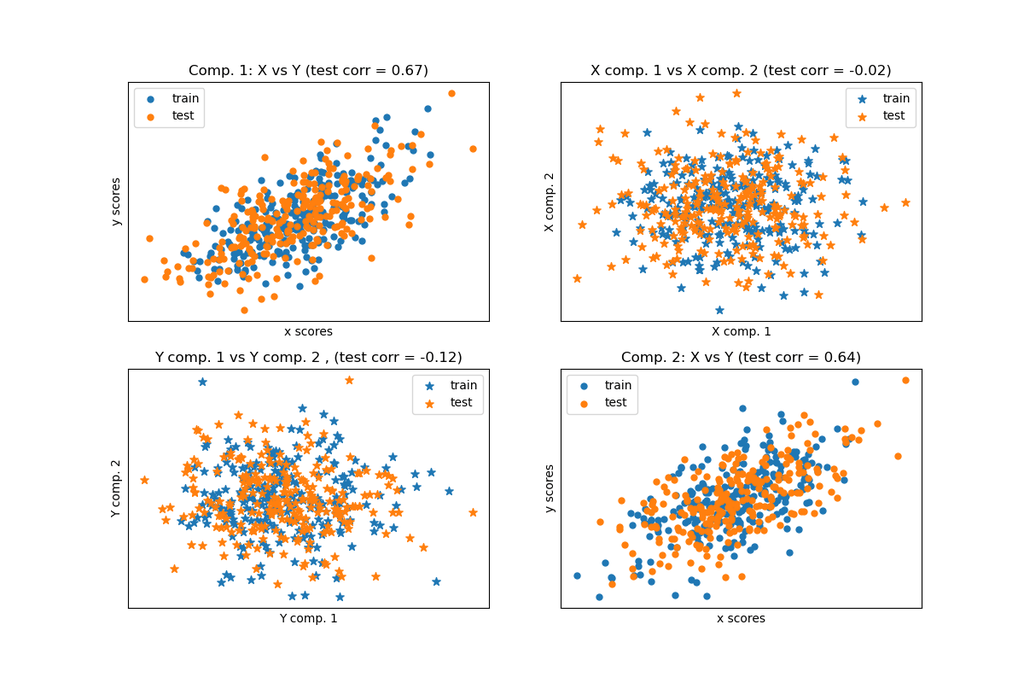

## PLS regression, with multivariate response, a.k.a. PLS2

```
from sklearn.cross_decomposition import PLSRegression

n = 1000
q = 3
p = 10
X = np.random.normal(size=n * p).reshape((n, p))
B = np.array([[1, 2] + [0] * (p - 2)] * q).T
# each Yj = 1*X1 + 2*X2 + noize
Y = np.dot(X, B) + np.random.normal(size=n * q).reshape((n, q)) + 5

pls2 = PLSRegression(n_components=3)
pls2.fit(X, Y)
print("True B (such that: Y = XB + Err)")
print(B)
# compare pls2.coef_ with B
print("Estimated B")
print(np.round(pls2.coef_, 1))
pls2.predict(X)
```

```
True B (such that: Y = XB + Err)
[[1 1 1]
 [2 2 2]
 [0 0 0]
 [0 0 0]
 [0 0 0]
 [0 0 0]
 [0 0 0]
 [0 0 0]
 [0 0 0]
 [0 0 0]]
Estimated B
[[ 1.   2.   0.  -0.  -0.   0.   0.  -0.   0.   0. ]
 [ 1.   1.9  0.  -0.  -0.   0.1  0.   0.   0.   0. ]
 [ 1.   2.1 -0.   0.  -0.   0.   0.   0.   0.  -0. ]]

array([[4.11693539, 4.19803308, 4.12190903],
       [8.77322639, 8.77777215, 9.04995982],
       [5.34990341, 5.37257991, 5.27597342],
       ...,
       [5.95433992, 5.9403917 , 6.02818216],
       [5.06880943, 5.08604995, 5.05216586],
       [9.72295655, 9.70432034, 9.79769376]])
```

## PLS regression, with univariate response, a.k.a. PLS1

```
n = 1000
p = 10
X = np.random.normal(size=n * p).reshape((n, p))
y = X[:, 0] + 2 * X[:, 1] + np.random.normal(size=n * 1) + 5
pls1 = PLSRegression(n_components=3)
pls1.fit(X, y)
# note that the number of components exceeds 1 (the dimension of y)
print("Estimated betas")
print(np.round(pls1.coef_, 1))
```

```
Estimated betas
[[ 1.   2.  -0.1  0.  -0.  -0.  -0.   0.   0.  -0.1]]
```

## CCA (PLS mode B with symmetric deflation)

```
from sklearn.cross_decomposition import CCA

cca = CCA(n_components=2)
cca.fit(X_train, Y_train)
X_train_r, Y_train_r = cca.transform(X_train, Y_train)
X_test_r, Y_test_r = cca.transform(X_test, Y_test)
```

**Total running time of the script:** (0 minutes 0.206 seconds)

[figure not shown]

[`Download Jupyter notebook: plot_compare_cross_decomposition.ipynb`](https://scikit-learn.org/1.6/_downloads/0837676cf643e44f0684e848d0967551/plot_compare_cross_decomposition.ipynb)

[`Download Python source code: plot_compare_cross_decomposition.py`](https://scikit-learn.org/1.6/_downloads/4a508ac905c7935181ce08bd00a8cda9/plot_compare_cross_decomposition.py)

[`Download zipped: plot_compare_cross_decomposition.zip`](https://scikit-learn.org/1.6/_downloads/6a464fa14bf1d3ca99fc9a199d81a8b3/plot_compare_cross_decomposition.zip)

#### Related examples

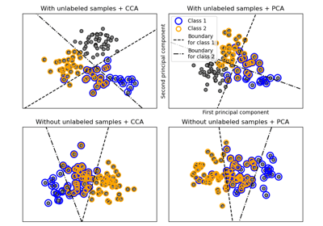

Multilabel classification

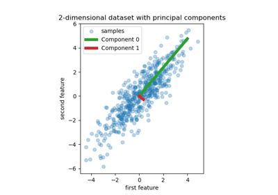

Principal Component Regression vs Partial Least Squares Regression

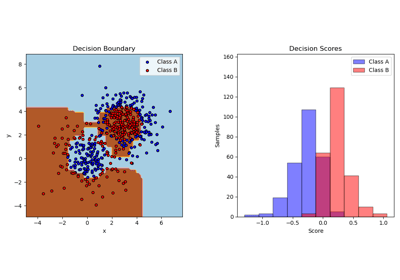

Two-class AdaBoost

Semi-supervised Classification on a Text Dataset

© 2007–2025 The scikit-learn developers  
Licensed under the 3-clause BSD License.  
https://scikit-learn.org/1.6/auto_examples/cross_decomposition/plot_compare_cross_decomposition.html